# Taxon-Taxon Associations: Co-occurrence

Hanna Berman

8/8/2019

# Set up

Packages

```r
library(tidyverse)
library(vegan)
library(cooccur)
```

File paths

```r
#metadata
sgDF <- file.path("..", "..", "shotgunMetadata.tsv") %>%
  read_tsv() %>%
  mutate(SampleID=as.character(SampleID))
#metaphlan data
load("metaphlanAbundances.Rdata")
```

Organize data frame

```r
DF <- sgDF %>%
  select(SampleID, SubjectID, Cohort, GDcoll) %>%
  left_join(mDF[,c("SampleID", "Gardnerella_vaginalis")], by="SampleID") %>%
  left_join(mDFG[,c("SampleID",
                    "Gardnerella_vaginalis_C1",
                    "Gardnerella_vaginalis_C2",
                    "Gardnerella_vaginalis_C3",
                    "Gardnerella_vaginalis_C4",
                    "Gardnerella_vaginalis_C5",
                    "Gardnerella_vaginalis_C6",
                    "Lactobacillus_crispatus",
                    "Lactobacillus_gasseri",
                    "Lactobacillus_jensenii",
                    "Lactobacillus_iners")],
            by="SampleID") %>%
  dplyr::rename(total_Gardnerella_vaginalis=Gardnerella_vaginalis) %>%
  mutate(Cohort=replace_na(Cohort, "unknown"))

DFpa <- DF %>% #presence, absence DF
  mutate_if(str_detect(colnames(.), "Gardnerella|Lactobacillus"),
            ~case_when(.x>0~1,
                       .x==0~0))

subsetSamples <- read_lines(file.path("..", "..", "sampleSubset.txt"))
```

Define the two groups of taxa pairs to assess: (six *Gardnerella vaginalis* clades and four *Lactobacillus* species, and total *Gardnerella vaginalis* and four *Lactobacilllus* species).

```r
# Taxa groups:
gardnerellaClades <- c("Gardnerella_vaginalis_C1", "Gardnerella_vaginalis_C2", "Gardnerella_vaginalis_C3", "Gardnerella_vaginalis_C4", "Gardnerella_vaginalis_C5", "Gardnerella_vaginalis_C6")
cladesLactos <- c("Gardnerella_vaginalis_C1", "Gardnerella_vaginalis_C2", "Gardnerella_vaginalis_C3", "Gardnerella_vaginalis_C4", "Gardnerella_vaginalis_C5", "Gardnerella_vaginalis_C6", "Lactobacillus_crispatus", "Lactobacillus_gasseri", "Lactobacillus_jensenii", "Lactobacillus_iners")
allGardLactos <- c("total_Gardnerella_vaginalis", "Lactobacillus_crispatus", "Lactobacillus_gasseri", "Lactobacillus_jensenii", "Lactobacillus_iners")
```

# Co-occurrence

Probabilistic assessment of cooccurrence performed using the `cooccur` R package  
Griffith D, Veech J, Marsh C. cooccur: Probabilistic Species Co-Occurrence Analysis in R. Journal of Statistical Software, Code Snippets. 2016;69(2):1–17.  
Based on:  
Veech JA. A probabilistic model for analysing species co-occurrence. Peres-Neto P, editor. Glob Ecol Biogeogr. 2013 Feb 22;22(2):252–60.

Use a hypergeometric distribution to test if co-occurrence occurs more or less than expected.

$p$ value for testing whether the observed number of co-occurrences ($Q_{obs}$) is less than expected can be calculated as the sum of the probability of seeing the two taxa co-occurr less than ($P_{lt}$) and equal to ($P_{et}$) $Q_{obs}$.

$p$ value for testing whether the observed number of co-occurrences ($Q_{obs}$) is greater than expected can be calculated as the sum of the probability of seeing the two taxa co-occurr greater than ($P_{gt}$) and equal to ($P_{et}$) $Q_{obs}$.

Effect size is the difference between observed and expected co-occurrences, normalized to the number of sites.

## Define functions

Make a function to perform and plot analyses for convenience.

```r
cooccurr_analyses <- function(cohort, samples, organisms){
  x <- DFpa %>%
    filter(Cohort==cohort,
          is.element(SampleID, samples)) %>%
    select(organisms) %>%
    select_if(~sum(.x)!=0) %>%
    t() %>%
    as.matrix() %>%
    cooccur(., type="spp_site", spp_names=TRUE, prob="hyper", eff_standard=TRUE, thresh=FALSE)

  x0 <- x$results %>%
    select(sp1_name, sp2_name, p_lt, p_gt) %>%
    mutate(sp1_name=as.character(sp1_name),
           sp2_name=as.character(sp2_name))

  x1 <- x %>%
    effect.sizes() %>%
    dplyr::rename(sp1_name=sp1,
                  sp2_name=sp2) %>%
    mutate(sp1_name=as.character(sp1_name),
           sp2_name=as.character(sp2_name)) %>%
    left_join(x0, by=c("sp1_name", "sp2_name")) %>%
    mutate(pvalue=case_when(p_lt>0.05&p_gt>0.05~"",
                            p_lt<=0.05&p_lt>0.01~"*",
                            p_gt<=0.05&p_gt>0.01~"*",
                            p_lt<=0.01&p_lt>0.005~"**",
                            p_gt<=0.01&p_gt>0.005~"**",
                            p_lt<=0.005&p_lt>0.001~"***",
                            p_gt<=0.005&p_gt>0.001~"***",
                            p_lt<=0.001&p_lt>0.0001~"****",
                            p_gt<=0.001&p_gt>0.0001~"****",
                            p_lt<=0.0001~"*****",
                            p_gt<=0.0001~"*****"))

  samples <- ifelse(length(samples)==length(subsetSamples), "Sample Subset", "All Samples")
  title <- ifelse(length(organisms)==length(gardnerellaClades), "Co-occurrence of G. vaginalis clades and Lactobacillus spp.", "Co-occurrence of total G. vaginalis and Lactobacillus spp.")

  plot <- ggplot(x1, aes(x=sp1_name, y=sp2_name, fill=effects, label=pvalue)) +
    geom_tile() +
    geom_text()+
    scale_fill_gradient2(low = "red", mid = "white", high = "blue") +
    theme(axis.text.x = element_text(angle = 45, hjust=1)) +
    labs(title=title, subtitle = paste0(cohort, ": ", samples), x=NULL, y=NULL)
  return(list(Cooccur_summary=summary(x),
              Cooccur_results=x$results,
              Heatmap=plot))
}
```

In blue-red heat maps, color is the effect size (difference between observed and expected co-occurrences normalized by dividing by number of sites), asterisks reflect p values:  
$p≤0.05: *$  
$p≤0.01: **$  
$p≤0.005: ***$  
$p≤0.001: ****$  
$p≤0.0001: *****$

Note: With family-wise error rate of $\alpha = 0.05$, with 45 pair comparisons (six *Gardnerella vaginalis* clades and four *Lactobacillus* species), adjusted $\alpha$ = $0.00\bar{1}$, and with 10 pairs, (total *Gardnerella vaginalis* and four *Lactobacilllus* species) the adjusted $\alpha$ = 0.005.

Analyses were performed on all samples from each cohort, and then a subset of one sample per subject randomly selected from the second trimester. Stanford: $N=62$ samples total from 20 subjects, subset $N=20$ samples. UAB: $N=45$ samples from 15 subjects, subset $N=14$ samples (subject 40047 did not have samples in the second trimester).

## Stanford

### All Samples

```r
cooccurr_analyses("Stanford", sgDF$SampleID, cladesLactos)
```

```
##
## Call:
## cooccur(mat = ., type = "spp_site", thresh = FALSE, spp_names = TRUE,
##     prob = "hyper", eff_standard = TRUE)
##
## 45 pairs were analyzed
##
## Cooccurrence Summary:
```

```
## $Cooccur_summary
##        Species          Sites       Positive       Negative         Random
##           10.0           62.0           11.0            9.0           25.0
## Unclassifiable Non-random (%)
##            0.0           44.4
## attr(,"class")
## [1] "summary.cooccur"
##
## $Cooccur_results
##    sp1 sp2 sp1_inc sp2_inc obs_cooccur prob_cooccur exp_cooccur    p_lt
## 1    1   2      35      26          21        0.237        14.7 0.99986
## 2    1   3      35      22          17        0.200        12.4 0.99730
## 3    1   4      35      35          23        0.319        19.8 0.97362
## 4    1   5      35      14          14        0.127         7.9 1.00000
## 5    1   6      35      13           9        0.118         7.3 0.91485
```

[output cut: 88 more lines]

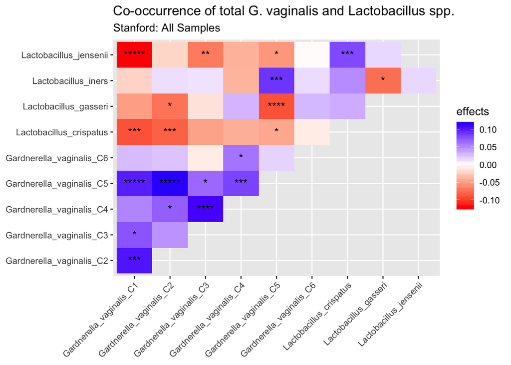

```r
cooccurr_analyses("Stanford", sgDF$SampleID, allGardLactos)
```

```
##
## Call:
## cooccur(mat = ., type = "spp_site", thresh = FALSE, spp_names = TRUE,
##     prob = "hyper", eff_standard = TRUE)
##
## 10 pairs were analyzed
##
## Cooccurrence Summary:
```

```
## $Cooccur_summary
##        Species          Sites       Positive       Negative         Random
##              5             62              2              3              5
## Unclassifiable Non-random (%)
##              0             50
## attr(,"class")
## [1] "summary.cooccur"
##
## $Cooccur_results
##    sp1 sp2 sp1_inc sp2_inc obs_cooccur prob_cooccur exp_cooccur    p_lt
## 1    1   2      53      17          13        0.234        14.5 0.19844
## 2    1   3      53      25          25        0.345        21.4 1.00000
## 3    1   4      53      15          10        0.207        12.8 0.03076
## 4    1   5      53      29          21        0.400        24.8 0.00748
## 5    2   3      17      25           9        0.111         6.9 0.93691
## 6    2   4      17      15           9        0.066         4.1 0.99972
## 7    2   5      17      29          11        0.128         8.0 0.97896
## 8    3   4      25      15           7        0.098         6.0 0.81034
## 9    3   5      25      29           7        0.189        11.7 0.01414
## 10   4   5      15      29           8        0.113         7.0 0.81104
##       p_gt                    sp1_name                sp2_name
## 1  0.94489 total_Gardnerella_vaginalis Lactobacillus_crispatus
## 2  0.00613 total_Gardnerella_vaginalis   Lactobacillus_gasseri
## 3  0.99564 total_Gardnerella_vaginalis  Lactobacillus_jensenii
## 4  0.99951 total_Gardnerella_vaginalis     Lactobacillus_iners
## 5  0.16973     Lactobacillus_crispatus   Lactobacillus_gasseri
## 6  0.00240     Lactobacillus_crispatus  Lactobacillus_jensenii
## 7  0.07285     Lactobacillus_crispatus     Lactobacillus_iners
## 8  0.38910       Lactobacillus_gasseri  Lactobacillus_jensenii
## 9  0.99684       Lactobacillus_gasseri     Lactobacillus_iners
## 10 0.38601      Lactobacillus_jensenii     Lactobacillus_iners
##
## $Heatmap
```

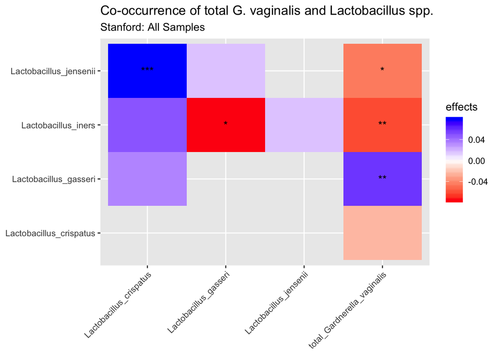

### Sample Subset

```r
cooccurr_analyses("Stanford", subsetSamples, cladesLactos)
```

```
##
## Call:
## cooccur(mat = ., type = "spp_site", thresh = FALSE, spp_names = TRUE,
##     prob = "hyper", eff_standard = TRUE)
##
## 45 pairs were analyzed
##
## Cooccurrence Summary:
```

```
## $Cooccur_summary
##        Species          Sites       Positive       Negative         Random
##           10.0           20.0            6.0            1.0           36.0
## Unclassifiable Non-random (%)
##            2.0           15.6
## attr(,"class")
## [1] "summary.cooccur"
##
## $Cooccur_results
##    sp1 sp2 sp1_inc sp2_inc obs_cooccur prob_cooccur exp_cooccur    p_lt
## 1    1   2      11       8           7        0.220         4.4 0.99869
## 2    1   3      11       7           6        0.192         3.8 0.99574
## 3    1   4      11      11           8        0.303         6.1 0.98762
## 4    1   5      11       5           5        0.138         2.8 1.00000
## 5    1   6      11       4           2        0.110         2.2 0.62539
```

[output cut: 88 more lines]

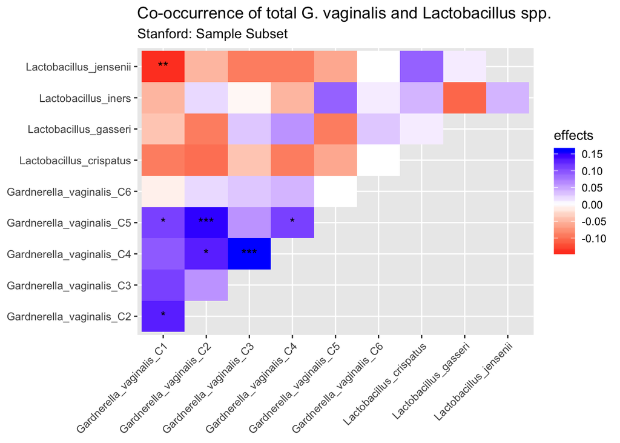

```r
cooccurr_analyses("Stanford", subsetSamples, allGardLactos)
```

```
##
## Call:
## cooccur(mat = ., type = "spp_site", thresh = FALSE, spp_names = TRUE,
##     prob = "hyper", eff_standard = TRUE)
##
## 10 pairs were analyzed
##
## Cooccurrence Summary:
```

```
## $Cooccur_summary
##        Species          Sites       Positive       Negative         Random
##              5             20              0              1              8
## Unclassifiable Non-random (%)
##              1             10
## attr(,"class")
## [1] "summary.cooccur"
##
## $Cooccur_results
##    sp1 sp2 sp1_inc sp2_inc obs_cooccur prob_cooccur exp_cooccur    p_lt
## 1    1   2      16       5           3        0.200         4.0 0.24871
## 2    1   3      16       7           7        0.280         5.6 1.00000
## 3    1   4      16       5           2        0.200         4.0 0.03199
## 4    1   5      16       9           6        0.360         7.2 0.21672
## 5    2   3       5       7           2        0.088         1.8 0.79321
## 6    2   4       5       5           3        0.062         1.2 0.99510
## 7    2   5       5       9           3        0.112         2.2 0.90248
## 8    3   4       7       5           2        0.088         1.8 0.79321
## 9    3   5       7       9           1        0.158         3.1 0.05789
## 10   4   5       5       9           3        0.112         2.2 0.90248
##       p_gt                    sp1_name                sp2_name
## 1  0.96801 total_Gardnerella_vaginalis Lactobacillus_crispatus
## 2  0.14757 total_Gardnerella_vaginalis   Lactobacillus_gasseri
## 3  0.99897 total_Gardnerella_vaginalis  Lactobacillus_jensenii
## 4  0.97399 total_Gardnerella_vaginalis     Lactobacillus_iners
## 5  0.59417     Lactobacillus_crispatus   Lactobacillus_gasseri
## 6  0.07263     Lactobacillus_crispatus  Lactobacillus_jensenii
## 7  0.39551     Lactobacillus_crispatus     Lactobacillus_iners
## 8  0.59417       Lactobacillus_gasseri  Lactobacillus_jensenii
## 9  0.99574       Lactobacillus_gasseri     Lactobacillus_iners
## 10 0.39551      Lactobacillus_jensenii     Lactobacillus_iners
##
## $Heatmap
```

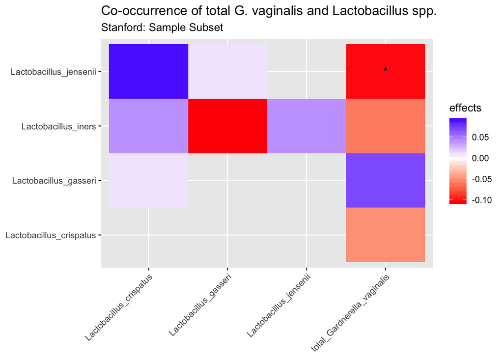

## UAB

### All Samples

```r
cooccurr_analyses("UAB", sgDF$SampleID, cladesLactos)
```

```
##
## Call:
## cooccur(mat = ., type = "spp_site", thresh = FALSE, spp_names = TRUE,
##     prob = "hyper", eff_standard = TRUE)
##
## 45 pairs were analyzed
##
## Cooccurrence Summary:
```

```
## $Cooccur_summary
##        Species          Sites       Positive       Negative         Random
##           10.0           45.0           10.0            4.0           31.0
## Unclassifiable Non-random (%)
##            0.0           31.1
## attr(,"class")
## [1] "summary.cooccur"
##
## $Cooccur_results
##    sp1 sp2 sp1_inc sp2_inc obs_cooccur prob_cooccur exp_cooccur    p_lt
## 1    1   2      40      40          38        0.790        35.6 0.99984
## 2    1   3      40      36          35        0.711        32.0 0.99990
## 3    1   4      40      36          34        0.711        32.0 0.99618
## 4    1   5      40      25          25        0.494        22.2 1.00000
## 5    1   6      40      27          26        0.533        24.0 0.99299
```

[output cut: 88 more lines]

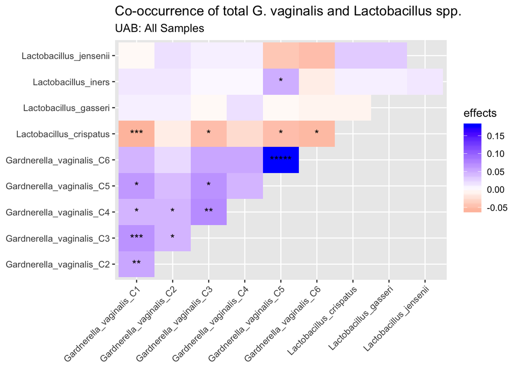

```r
cooccurr_analyses("UAB", sgDF$SampleID, allGardLactos)
```

```
##
## Call:
## cooccur(mat = ., type = "spp_site", thresh = FALSE, spp_names = TRUE,
##     prob = "hyper", eff_standard = TRUE)
##
## 10 pairs were analyzed
##
## Cooccurrence Summary:
```

```
## $Cooccur_summary
##        Species          Sites       Positive       Negative         Random
##              5             45              0              0             10
## Unclassifiable Non-random (%)
##              0              0
## attr(,"class")
## [1] "summary.cooccur"
##
## $Cooccur_results
##    sp1 sp2 sp1_inc sp2_inc obs_cooccur prob_cooccur exp_cooccur    p_lt
## 1    1   2      43       4           3        0.085         3.8 0.17172
## 2    1   3      43       4           4        0.085         3.8 1.00000
## 3    1   4      43       7           7        0.149         6.7 1.00000
## 4    1   5      43      41          39        0.871        39.2 0.82828
## 5    2   3       4       4           0        0.008         0.4 0.67969
## 6    2   4       4       7           2        0.014         0.6 0.99084
## 7    2   5       4      41           4        0.081         3.6 1.00000
## 8    3   4       4       7           2        0.014         0.6 0.99084
## 9    3   5       4      41           4        0.081         3.6 1.00000
## 10   4   5       7      41           7        0.142         6.4 1.00000
##       p_gt                    sp1_name                sp2_name
## 1  0.99394 total_Gardnerella_vaginalis Lactobacillus_crispatus
## 2  0.82828 total_Gardnerella_vaginalis   Lactobacillus_gasseri
## 3  0.71010 total_Gardnerella_vaginalis  Lactobacillus_jensenii
## 4  1.00000 total_Gardnerella_vaginalis     Lactobacillus_iners
## 5  1.00000     Lactobacillus_crispatus   Lactobacillus_gasseri
## 6  0.10825     Lactobacillus_crispatus  Lactobacillus_jensenii
## 7  0.67969     Lactobacillus_crispatus     Lactobacillus_iners
## 8  0.10825       Lactobacillus_gasseri  Lactobacillus_jensenii
## 9  0.67969       Lactobacillus_gasseri     Lactobacillus_iners
## 10 0.49542      Lactobacillus_jensenii     Lactobacillus_iners
##
## $Heatmap
```

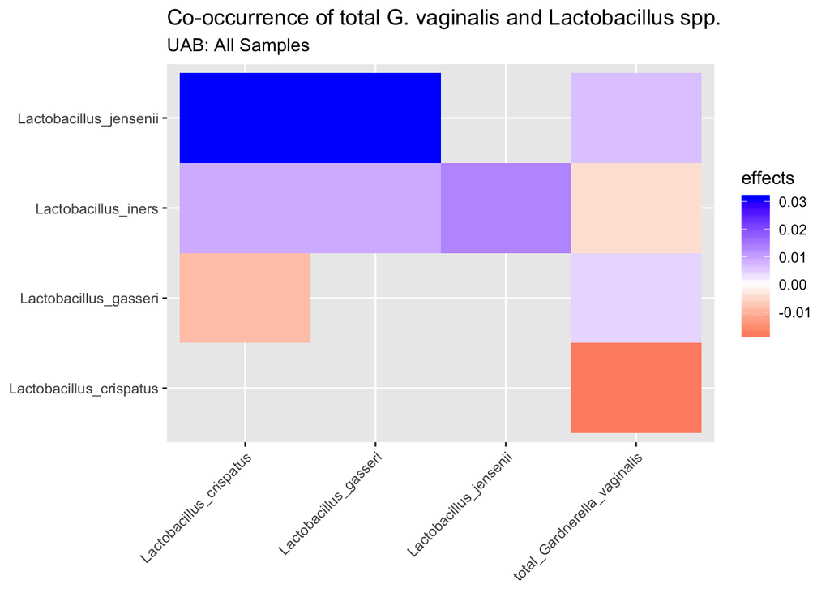

### Sample Subset

```r
cooccurr_analyses("UAB", subsetSamples, cladesLactos)
```

```
##
## Call:
## cooccur(mat = ., type = "spp_site", thresh = FALSE, spp_names = TRUE,
##     prob = "hyper", eff_standard = TRUE)
##
## 36 pairs were analyzed
##
## Cooccurrence Summary:
```

```
## $Cooccur_summary
##        Species          Sites       Positive       Negative         Random
##            9.0           14.0            2.0            0.0           33.0
## Unclassifiable Non-random (%)
##            1.0            5.6
## attr(,"class")
## [1] "summary.cooccur"
##
## $Cooccur_results
##    sp1 sp2 sp1_inc sp2_inc obs_cooccur prob_cooccur exp_cooccur    p_lt
## 1    1   2      14      13          13        0.929        13.0 1.00000
## 2    1   3      14      12          12        0.857        12.0 1.00000
## 3    1   4      14      11          11        0.786        11.0 1.00000
## 4    1   5      14       7           7        0.500         7.0 1.00000
## 5    1   6      14       9           9        0.643         9.0 1.00000
```

[output cut: 70 more lines]

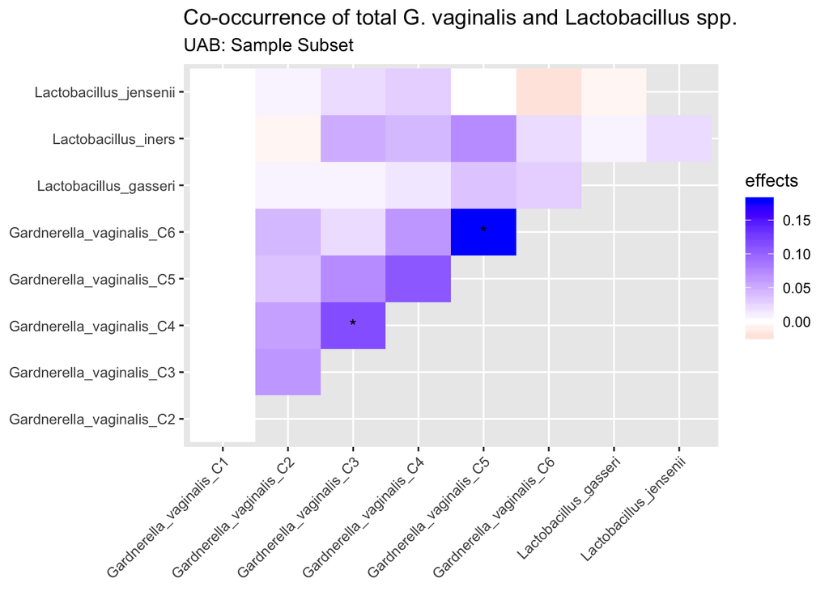

```r
cooccurr_analyses("UAB", subsetSamples, allGardLactos)
```

```
##
## Call:
## cooccur(mat = ., type = "spp_site", thresh = FALSE, spp_names = TRUE,
##     prob = "hyper", eff_standard = TRUE)
##
## 6 pairs were analyzed
##
## Cooccurrence Summary:
```

```
## $Cooccur_summary
##        Species          Sites       Positive       Negative         Random
##              4             14              0              0              6
## Unclassifiable Non-random (%)
##              0              0
## attr(,"class")
## [1] "summary.cooccur"
##
## $Cooccur_results
##   sp1 sp2 sp1_inc sp2_inc obs_cooccur prob_cooccur exp_cooccur    p_lt
## 1   1   2      14       1           1        0.071         1.0 1.00000
## 2   1   3      14       2           2        0.143         2.0 1.00000
## 3   1   4      14      12          12        0.857        12.0 1.00000
## 4   2   3       1       2           0        0.010         0.1 0.85714
## 5   2   4       1      12           1        0.061         0.9 1.00000
## 6   3   4       2      12           2        0.122         1.7 1.00000
##      p_gt                    sp1_name               sp2_name
## 1 1.00000 total_Gardnerella_vaginalis  Lactobacillus_gasseri
## 2 1.00000 total_Gardnerella_vaginalis Lactobacillus_jensenii
## 3 1.00000 total_Gardnerella_vaginalis    Lactobacillus_iners
## 4 1.00000       Lactobacillus_gasseri Lactobacillus_jensenii
## 5 0.85714       Lactobacillus_gasseri    Lactobacillus_iners
## 6 0.72527      Lactobacillus_jensenii    Lactobacillus_iners
##
## $Heatmap
```

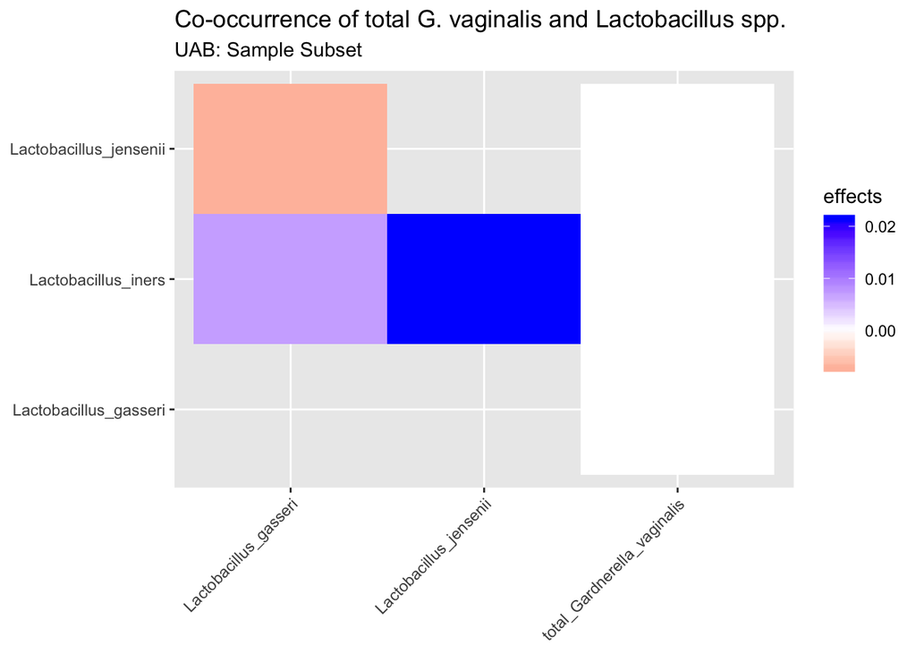

Note: no *L. crispatus* in any of the randomly selected subset samples in the UAB cohort.

Overall, results support previous findings that Gv less associated with Lactobaillus spp., whereas Gv clades may cooccurr. C5 may co-occur with L. iners (small trend found in both cohorts.) Not significant, but consistently greatest effects in exclusion with C1, C2 and C5 and Lactos (except C5 and L. iners). However, this method has low power with few sample sites (Veech, 2013), which may affect the ability to interpret results.